# ABARESdocs test report

An open source document production system

Neal Hughes

2 December 2016

# Charts

ABARESdocs uses some Python scripts to generate nicely formated chart images. For more information on how this works see the charts folder.

Once chart image files and table text files have been generated they can be inserted as below. Pandoc supports numbering and cross-referencing of tables and charts.

## Simple charts

Here is a line chart (Figure 1)

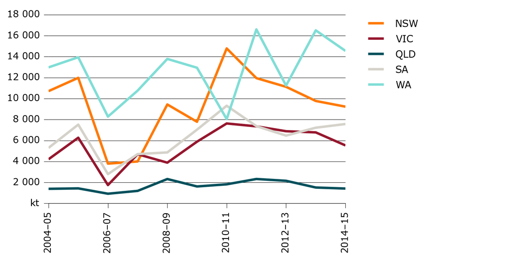

Figure 1: Line chart showing winter crop production in Australia, 2004-05 to 2014-15

Here is an area chart (Figure 2)

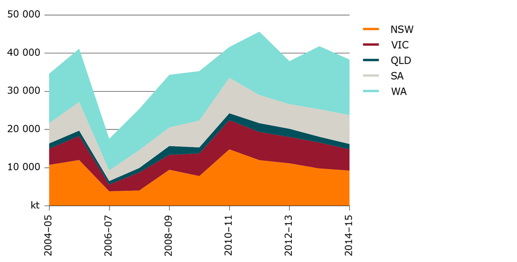

Figure 2: Area chart showing winter crop production in Australia, 2004-05 to 2014-15

Here is a bar chart (Figure 3)

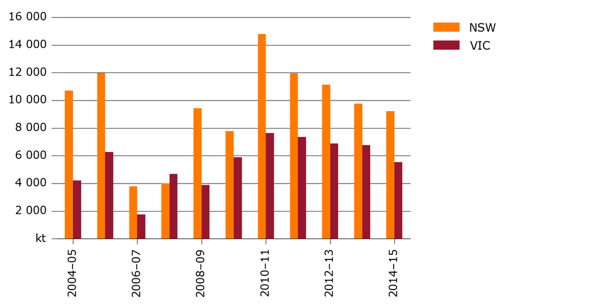

Figure 3: Bar chart showing winter crop production in Australia, 2004-05 to 2014-15

Here is a horizontal bar chart (Figure 4)

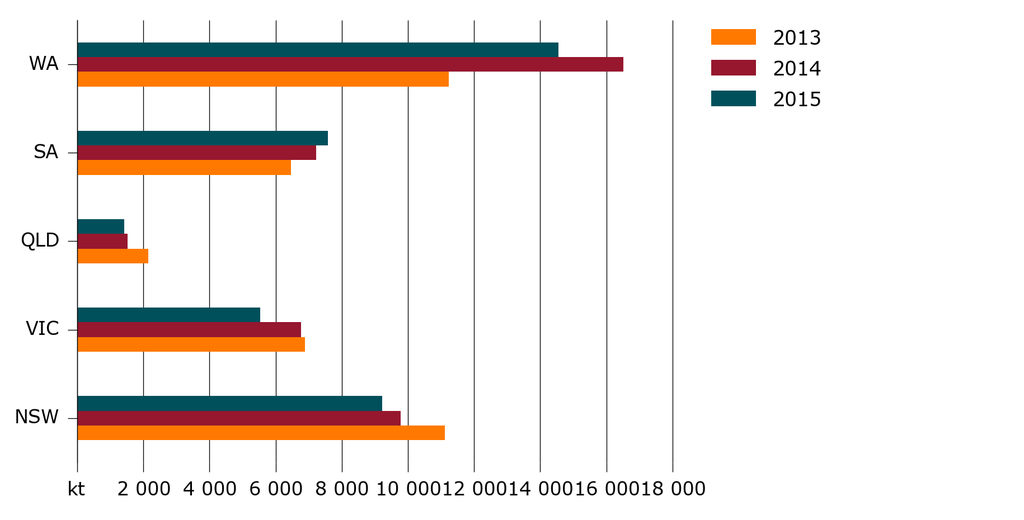

Figure 4: Horizontal Bar chart showing winter crop production in Australia, 2012-13 to 2014-15

Here is a stacked bar chart (Figure 5)

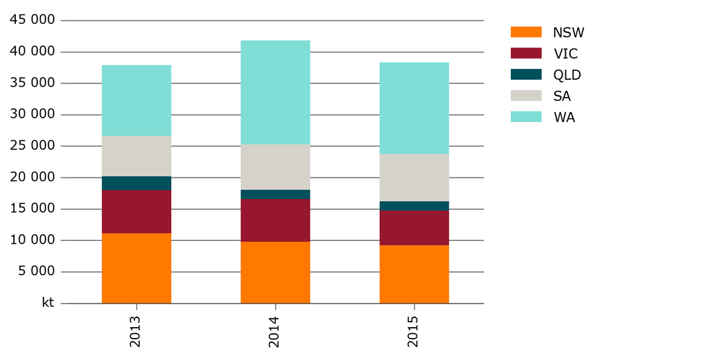

Figure 5: Stacked bar chart showing winter crop production in Australia, 2012-13 to 2014-15

Here is a scatter chart (Figure 6)

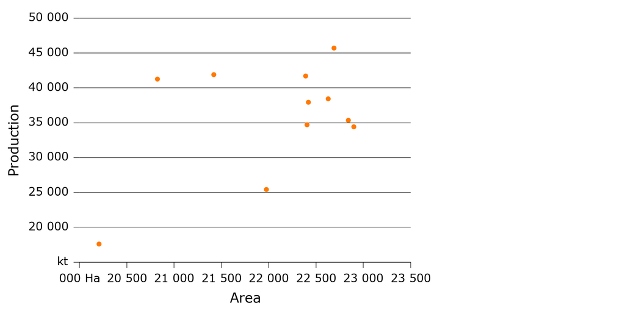

Figure 6: Scatter chart showing winter crop production in Australia against area, 2004-05 to 2014-15

Here is a multi-scatter chart (Figure 7)

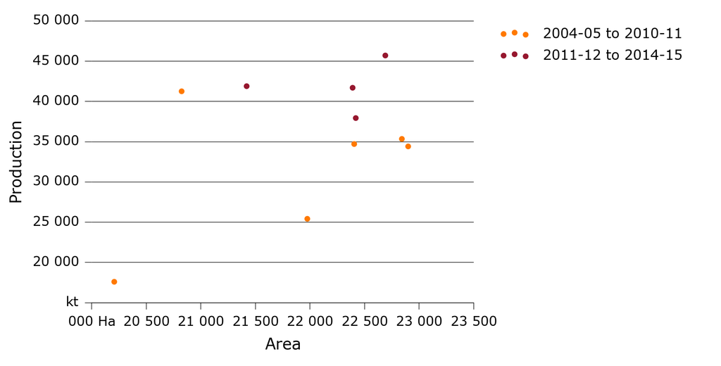

Figure 7: Multi-scatter chart showing winter crop production in Australia against area, 2004-05 to 2014-15

## Combo charts

Here is a line chart with secondary y-axis (Figure 8)

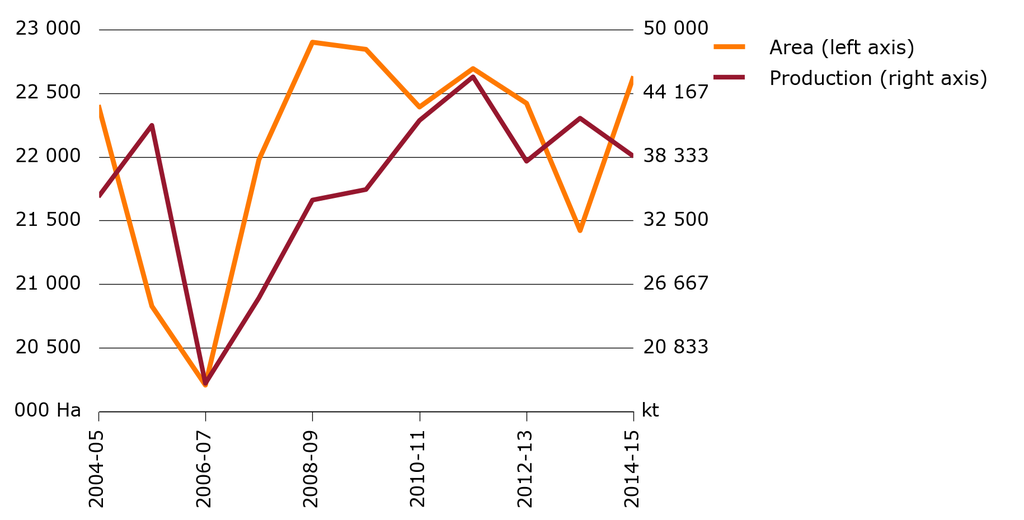

Figure 8: Line chart with secondary y-axis showing winter crop production and area in Australia, 2004-05 to 2014-15

Here is a bar and line chart with secondary y-axis (Figure 9)

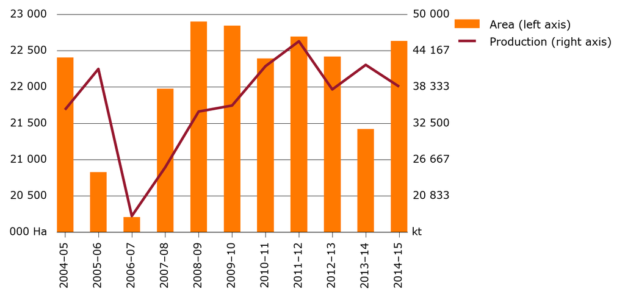

Figure 9: Bar and line chart showing winter crop production and area in Australia, 2004-05 to 2014-15

Here is an area and line chart with secondary y-axis (Figure 10)

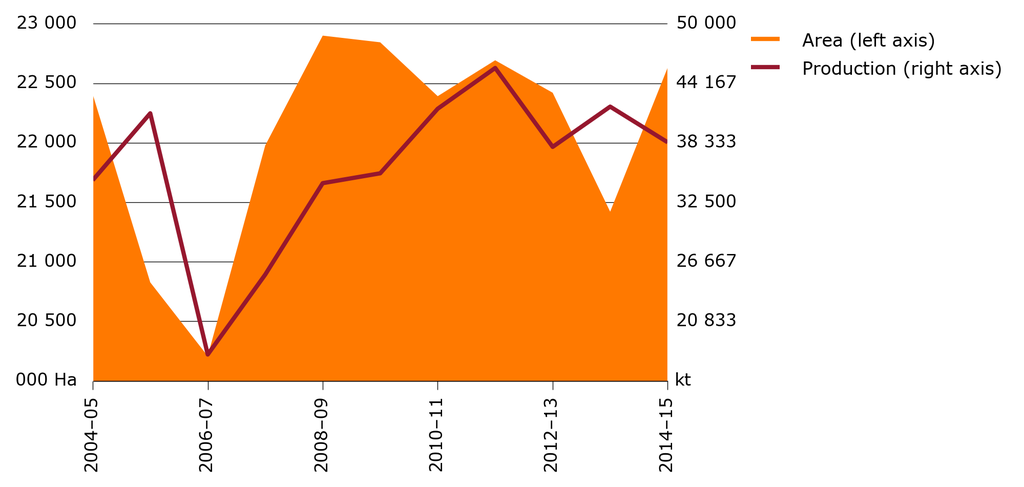

Figure 10: Area and line chart showing winter crop production and area in Australia, 2004-05 to 2014-15

## Panel charts

Here is a panel line chart (Figure 11)

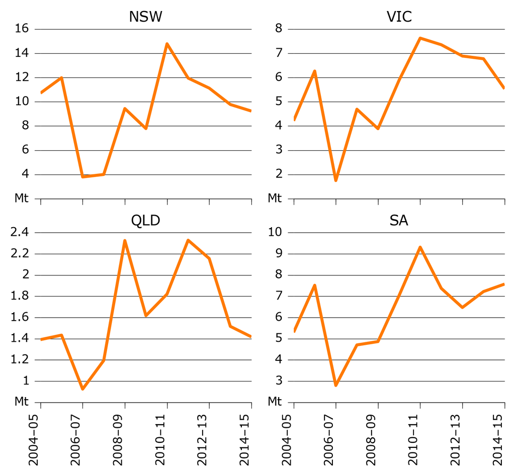

Figure 11: Panel chart showing winter crop production in Australia, 2004-05 to 2014-15

Here is a panel bar chart (Figure 12)

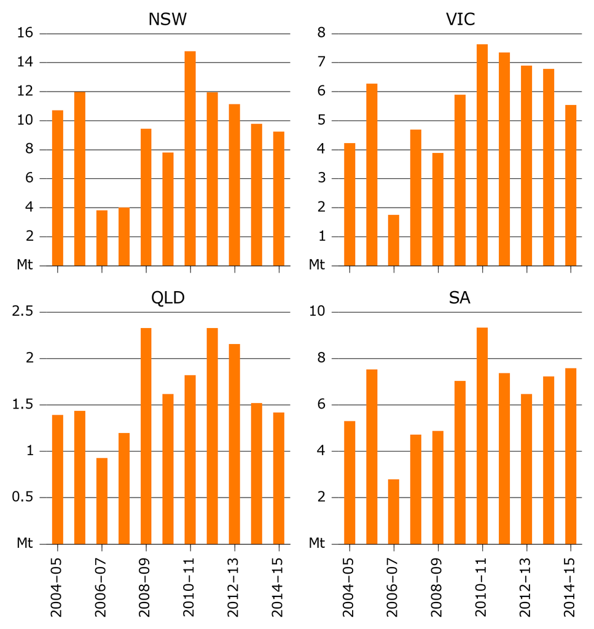

Figure 12: Panel bar chart showing winter crop production in Australia, 2004-05 to 2014-15

Here is a multi-panel chart (Figure 13)

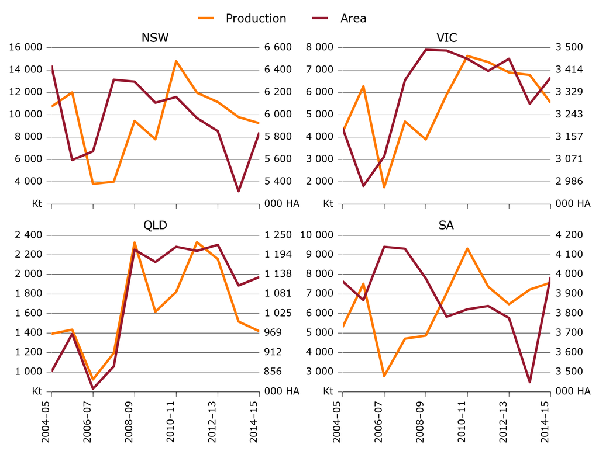

Figure 13: Multi panel chart showing winter crop production and area in Australia, 2004-05 to 2014-15

Here is a multi-panel bar / line chart (Figure 14)

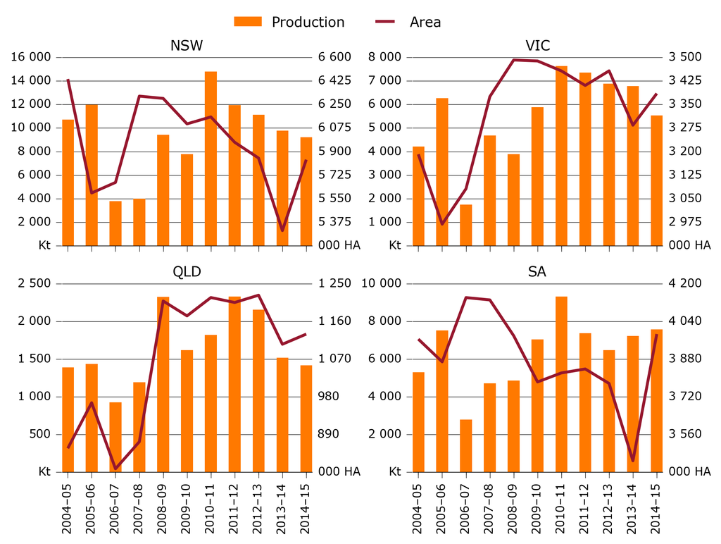

Figure 14: Multi panel bar/line chart showing winter crop production and area in Australia, 2004-05 to 2014-15